# Wombat Grylls sp. z o.o.

Aleksandra Olczyk, Aleksandra Czujowska, Anastazja Kopycińska, Wiktoria Jarząb, Dominika Szulc

2025-01-16

# 1 Informacje o firmie

- **Liczba placówek:** 1
- **Lokalizacja:** Wrocław
- **Data pierwszej transakcji:** 2020-03-10
- **Liczba pracowników:** 40
- **Kierunki wycieczek:** Islandia, Irlandia, Dania, Szwajcaria, Szwecja, Polska, Albania, Bułgaria, Brazylia, Czechy, Maroko, Norwegia, Peru, Anglia, Węgry, Singapur, RPA, Austria, Włochy, Malta, Belgia, Litwa, Holandia, Portugalia, Francja, Chorwacja, Niemcy, Finlandia, Hiszpania

# 2 Zainteresowanie firmą

## 2.1 Najpopularniejsze wycieczki

Zerknijmy na 3 najpopularniejsze wycieczki w naszej firmie. Porównując ich koszta i zyski możemy sprawdzić, czy są one dla nas opłacalne.

Koszta i zyski z 3 najpopularniejszych wycieczek

| nazwa_wycieczki | ilość_wycieczek | średni_koszt | średni_zysk | bilans |
| --- | --- | --- | --- | --- |
| Lądowanie helikopterem w dżungli | 15 | 1133.254 | 12633.33 | 11500.08 |
| Nurkowanie z rekinami | 10 | 2413.009 | 12806.00 | 10392.99 |
| Wspinaczka na wulkan | 10 | 2888.184 | 16477.00 | 13588.82 |

Na podstawie powyższej tabeli możemy stwierdzić, że:

- Lądowanie helikopterem w dżungli jest wycieczką **opłacalną** dla firmy pod względem zysków.
- Nurkowanie z rekinami jest wycieczką **opłacalną** dla firmy pod względem zysków.
- Wspinaczka na wulkan jest wycieczką **opłacalną** dla firmy pod względem zysków.

## 2.2 Prosperowanie firmy

Zdecydowaliśmy się sporządzić wykres liczby obsłużonych klientów w każdym miesiącu działalności firmy. Na tej podstawie sprawdzimy, czy firma rośnie, czy jednak chyli się ku upadkowi.

Robimy to, patrząc na datę transakcji - datę zakupienia wycieczki - i sprawdzamy, ile osób jest do tej wycieczki przypisanych. Skutkuje to tym, że jeśli w dany miesiącu nie było żadnej transakcji, oznacza to, że nie było wtedy klientów, ale nie jest to równoważne temu, że nikt nie brał wtedy udziału w żadnej wycieczce.

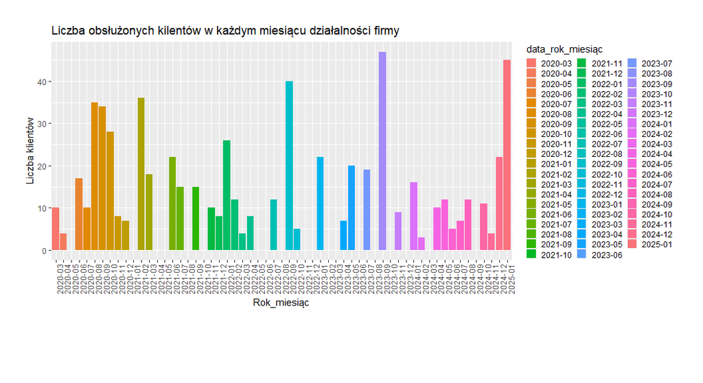

Spójrzmy zatem jeszcze na to, ile klientów pojechało na wyjazdy rozpoczynające się w każdym miesiącu pracy firmy.

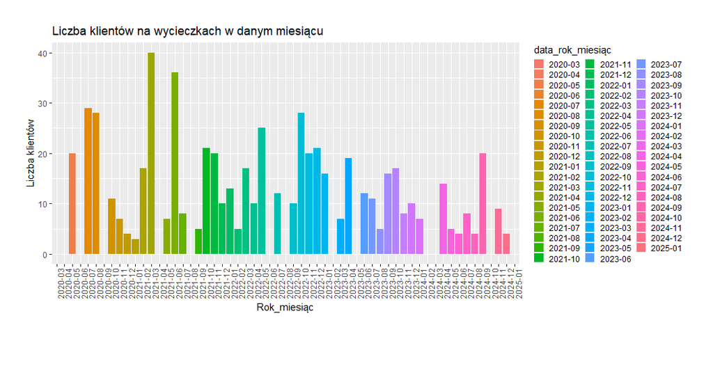

Liczba klientów na wycieczkach w danym miesiącu

**Wniosek:** Były miesiące, w których nie było ani jednej transakcji, ale rozpoczęły się wycieczki. Ten fakt mógł spowodować, że klienci nie kupowali u nas wycieczek - byli na wyjeździe. W 2021-04, 2021-08, 2022-06, 2022-08, 2023-02, 2024-03 nie zanotowaliśmy ani jednej transakcji oraz nikt nie był na wycieczce. Były to trudne momenty dla firmy.

# 3 Ku świetności

## 3.1 Bezpieczeństwo płatności

Zastanówmy się, czy nie byłoby rozsądnie usunąć możliwość płacenia gotówką. Zmniejszy to niebezpieczeństwo związane z posiadania gotówki w placówce oraz ewntualnej potrzeby przewożenia jej do banku w celu wpłacenia na konto.

Sprawdźmy, jakimi formami płatności posługują się nasi klienci.

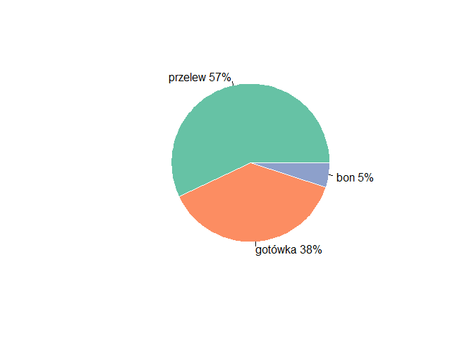

Rodzaje transakcji klientów

| typ_transakcji | ilość_transakcji | procent_transakcji |
| --- | --- | --- |
| przelew | 57 | 57% |
| gotówka | 38 | 38% |
| bon | 5 | 5% |

Najpopularniejszym typem transakcji jest przelew.

A teraz porównajmy to w zależności od przedziału wiekowego.

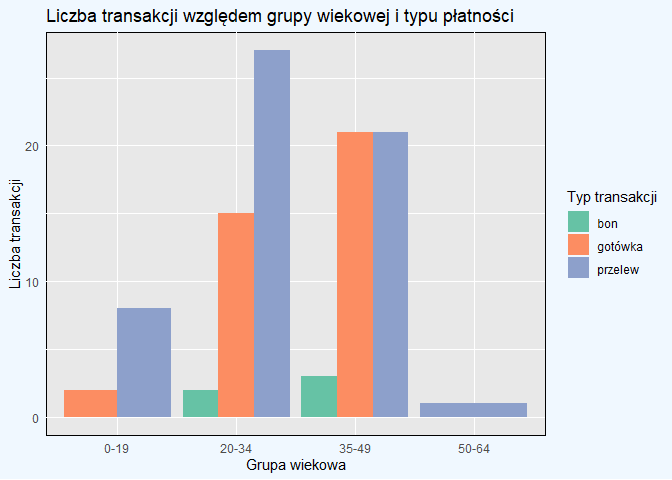

Liczba transakcji według typu i grupy wiekowej

| typ_transakcji | grupa_wiekowa | ilość | procent_transakcji |
| --- | --- | --- | --- |
| bon | 20-34 | 2 | 40% |
| bon | 35-49 | 3 | 60% |
| gotówka | 0-19 | 2 | 5.26% |
| gotówka | 20-34 | 15 | 39.47% |
| gotówka | 35-49 | 21 | 55.26% |
| przelew | 0-19 | 8 | 14.04% |
| przelew | 20-34 | 27 | 47.37% |
| przelew | 35-49 | 21 | 36.84% |
| przelew | 50-64 | 1 | 1.75% |

## 3.2 Bonusy

Dla powracających kupujących mamy jednorazową zniżkę na następny wyjazd. Kiedy kupili już jedną wycieczkę, to dostaną rabat w wysokości 3%, a w przypadku wykupienia dwóch albo większej ilości wycieczek, to rabat wyniesie 5%.

Rabat na następny wyjazd 3%

| nazwisko | imię | rabat |
| --- | --- | --- |
| Barcz | ANTONI | 3% |
| Barteczko | MIA | 3% |
| Burkiewicz | ARTUR | 3% |
| Chmielak | KSAWERY | 3% |
| Dela | HANNA | 3% |
| Durlej | ANTONI | 3% |
| Godyń | MARCEL | 3% |
| Gołek | JAKUB | 3% |
| Gromala | MIŁOSZ | 3% |
| Gęgotek | ADAM | 3% |
| Hudzik | LAURA | 3% |
| Kaja | MACIEJ | 3% |
| Koral | MAJA | 3% |
| Krzykała | KRZYSZTOF | 3% |
| Kutnik | JOANNA | 3% |
| Lelito | JAN | 3% |
| Machowicz | JULIAN | 3% |
| Majorek | FRANCISZEK | 3% |
| Mitek | ANTONI | 3% |
| Namysło | WIKTORIA | 3% |
| Opalach | ELIZA | 3% |
| Paprotny | LEON | 3% |
| Petryk | JAN | 3% |
| Piechna | EMILIA | 3% |
| Piksa | BLANKA | 3% |
| Proch | LILIANA | 3% |
| Sadoch | ALEKSANDER | 3% |
| Skubis | OLIWIER | 3% |
| Stoltmann | DAWID | 3% |
| Swaczyna | MARCIN | 3% |
| Szelest | ALEKSANDER | 3% |
| Warmuz | ZOFIA | 3% |
| Wawrzynek | NIKOLA | 3% |
| Wudarczyk | JAN | 3% |
| Znojek | LENA | 3% |
| Łaszczyk | MARCELINA | 3% |
| Łobacz | MAJA | 3% |
| Łuczyk | OLAF | 3% |

Rabat na następny wyjazd 5%

| nazwisko | imię | rabat |
| --- | --- | --- |
| Barankiewicz | IGA | 5% |
| Białach | RAJA | 5% |
| Bobel | LILIANA | 5% |
| Broniek | NAWOJKA | 5% |
| Działa | JAKUB | 5% |
| Fryś | OLIWIA | 5% |
| Kazimierczyk | JULIA | 5% |
| Kolber | ADRIANNA | 5% |
| Koman | GABRIEL | 5% |
| Kosno | DORIAN | 5% |
| Krzyszczak | IGA | 5% |
| Kucharzyk | HANNA | 5% |
| Kuzior | MAX | 5% |
| Lubera | NIKODEM | 5% |
| Macheta | AMELIA | 5% |
| Pośnik | JULIAN | 5% |
| Przewoźny | ZUZANNA | 5% |
| Rozynek | LAURA | 5% |
| Stroka | ALICJA | 5% |
| Szlachcic | ALEKSANDER | 5% |
| Szymała | MICHAŁ | 5% |
| Tylka | OLIWIA | 5% |
| Wasiewicz | MAJA | 5% |
| Witaszek | TADEUSZ | 5% |
| Wojtyś | AURELIA | 5% |
| Zimniak | LAURA | 5% |

W sumie mamy 38 osób, którym przysługuje 3% rabatu oraz 26 osób, którym przysługuje 5% rabatu na kolejny wyjazd.

## 3.3 Istnieją wycieczki, które odstraszją klientów?

Sprawdźmy, po których wycieczkach klienci wracają na kolejne, a po których mają dość i więcej ich nie widzimy. Czy są takie, które być może powinny zniknąć z oferty?

Wycieczki i opuszczanie naszej firmy po wzięciu udziału

| nazwa_wycieczki | ilość_wycieczkowiczów | ilość_opuszczających | ilość_wracających | opuszczający_procent |
| --- | --- | --- | --- | --- |
| Samotna noc na bezludnej wyspie | 54 | 17 | 37 | 31.48% |
| Ucieczka z zatopionego statku | 28 | 7 | 21 | 25% |
| Wspinaczka na wulkan | 60 | 12 | 48 | 20% |
| Lądowanie helikopterem w dżungli | 104 | 16 | 88 | 15.38% |
| Noc w nawiedzonym domu | 53 | 8 | 45 | 15.09% |
| Nurkowanie z rekinami | 74 | 8 | 66 | 10.81% |
| Kolacja na wulkanie | 23 | 0 | 23 | 0% |
| Noc w kapsule nad przepaścią | 24 | 0 | 24 | 0% |

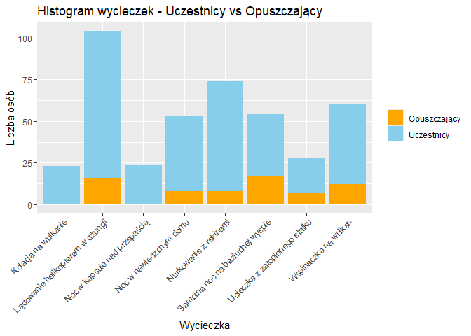

Nie mamy takiej wycieczki, po której 50% lub więcej wycieczkowiczów opuszcza naszą firmę.

## 3.4 Firma się rozrasta

Postanawiamy otworzyć w Polsce drugą placówkę z nadzieją, że zwiększy to naszą popularność i ułatwi dostępność. Gdzie moglibyśmy spodziewać się największej liczby klientów?

TOP10 miast z największą liczbą klientów

| województwo | miasto | liczba.klientów |
| --- | --- | --- |
| Kujawsko-Pomorskie | Janikowo | 5 |
| Kujawsko-Pomorskie | Kikół | 5 |
| Opolskie | Wołczyn | 5 |
| Dolnośląskie | Przemków | 4 |
| Kujawsko-Pomorskie | Ciechocinek | 4 |
| Świętokrzyskie | Nowy Korczyn | 4 |
| Lubelskie | Bełżyce | 3 |
| Lubuskie | Szlichtyngowa | 3 |
| Podkarpackie | Dukla | 3 |
| Pomorskie | Gniew | 3 |

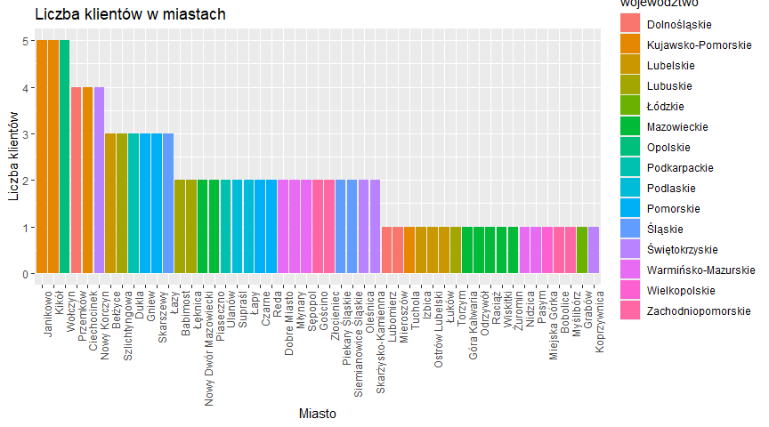

Mamy remis - więcej niż jedno miasto z taką samą liczbą klientów. Zatem wybieramy z nich to miasto, które jest w województwie z największą liczbą klientów.

| województwo | liczba.klientów |
| --- | --- |
| Kujawsko-Pomorskie | 10 |
| Opolskie | 5 |

**Wniosek:** Możemy otworzyć placówkę w Janikowo albo Kikół

### 3.4.1 Potrzeby budżetowe

Do otwarcia nowej placówki potrzebujemy dodatkowego budżetu (minimum 10000 złotych). Postanawiamy go uzyskać poprzez cięcia w kadrach. Zwalniamy agentów, którzy przeszli okres próbny (3 miesiące) i firma zarobiła na nich najmniej. O tym, ile osób straci pracę, zadecydują ich pensje (każdy agent ma identyczną stawkę brutto w wysokości 5126 złotych), które zagwarantują nam upragniony budżet.

Zarobek firmy na danym agencie

| id_pracownika | imię | nazwisko | zarobek_firmy |
| --- | --- | --- | --- |
| 15 | MIKOŁAJ | Niewiara | 161222.7 |
| 13 | KALINA | Korgul | 259335.0 |
| 17 | MIKOŁAJ | Tadeusiak | 266559.6 |
| 16 | JAN | Lenda | 281080.1 |
| 11 | IGNACY | Rząca | 308242.8 |
| 12 | MIA | Szczerbiak | 330756.5 |
| 14 | NATAN | Smagała | 369962.3 |

Liczba agentów do zwolnienia to 2. Zatem będą to następujące osoby:

Agenci do zwolnienia

| id_pracownika | imię | nazwisko | zarobek_firmy |
| --- | --- | --- | --- |
| 15 | MIKOŁAJ | Niewiara | 161222.7 |
| 13 | KALINA | Korgul | 259335.0 |